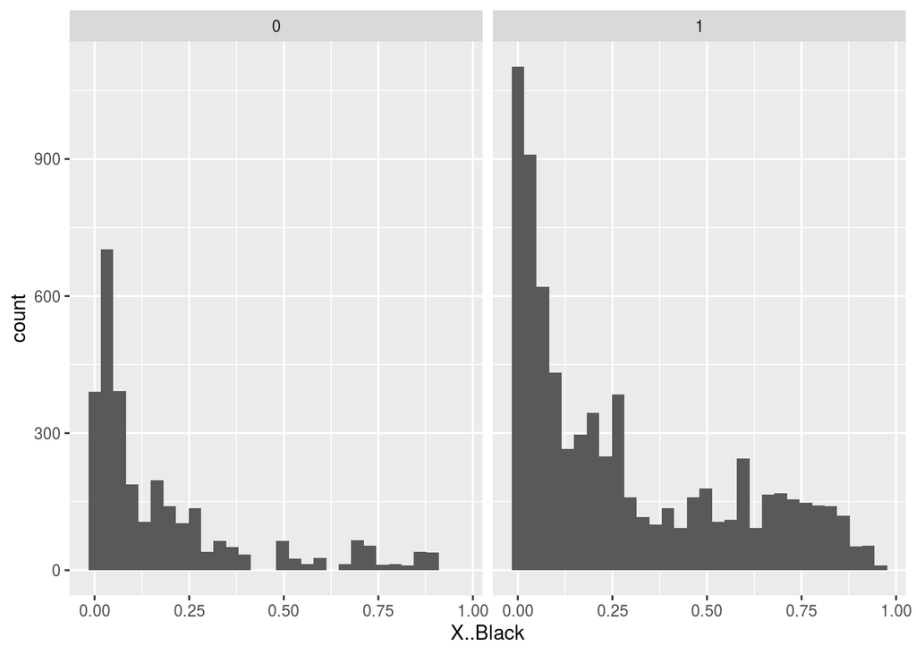

```r
# for whether or not it has a self-contained option
ggplot(data = third_grade_data) +
  geom_histogram(mapping = aes(x = X..Black)) +
  facet_wrap(~self_contained_option)
```

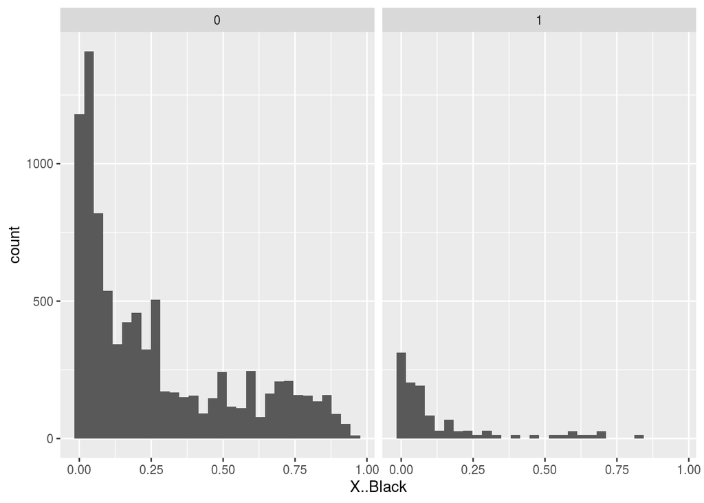

```r
ggplot(data = third_grade_data) +
  geom_histogram(mapping = aes(x = X..Black)) +
  facet_wrap(~gifted_talented_option)
```

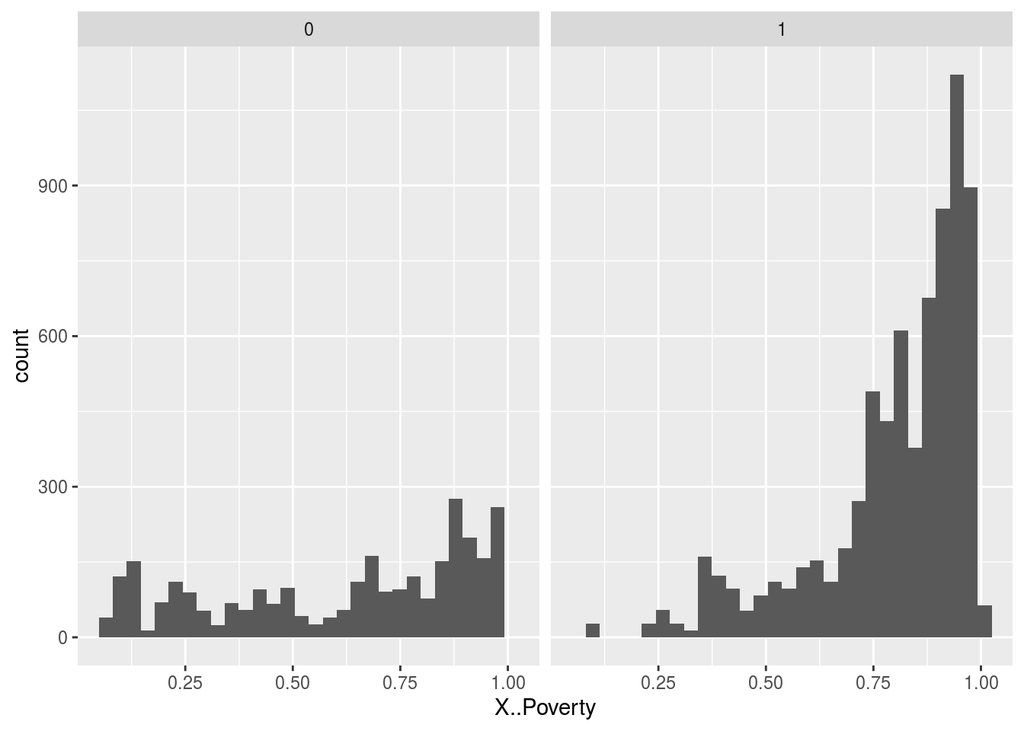

```r
ggplot(data = third_grade_data) +
  geom_histogram(mapping = aes(x = X..Poverty)) +
  facet_wrap(~self_contained_option)
```

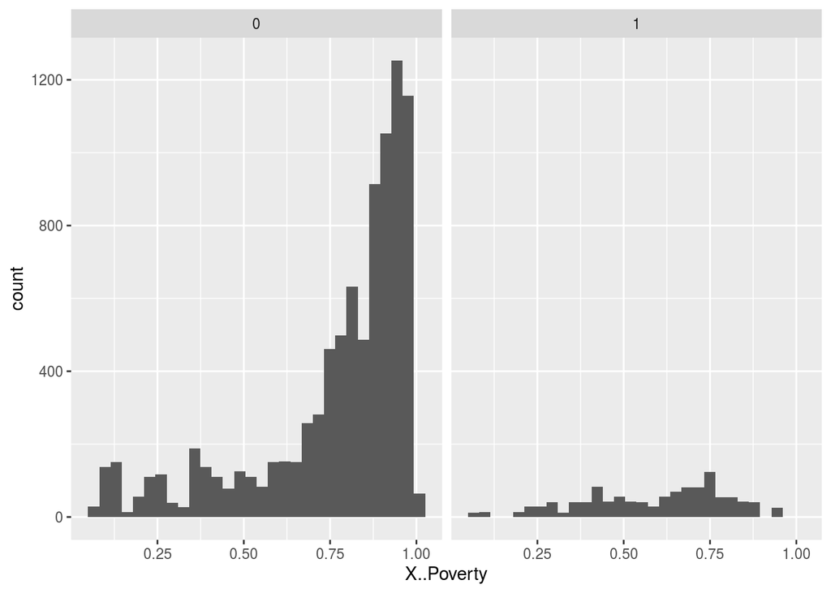

```r
ggplot(data = third_grade_data) +
  geom_histogram(mapping = aes(x = X..Poverty)) +
  facet_wrap(~gifted_talented_option)
```

```r
######
# STEP 3
#percent attendance for those with a self-contained option
#######
working_data <- working_data %>%
  filter(Percent_Attendance != 's') %>%
  filter(Percent_Chronically_Absent != 's')
working_data$Percent_Attendance <- as.numeric(working_data$Percent_Attendance)
attendance_compare <- working_data %>%
  group_by(self_contained_option, Demographic.Variable) %>%
  summarise(mean_attendance = mean(Percent_Attendance))
working_data %>%
  group_by(gifted_talented_option) %>%
  summarise(mean_attendance = mean(Percent_Attendance))
```

```
## # A tibble: 2 x 2
##   gifted_talented_option mean_attendance
##                    <dbl>           <dbl>
## 1                      0            93.2
## 2                      1            94.7
```

```r
write.csv(working_data, file = '/cloud/project/data/third_grade_data_cleaned.csv')
```

### Associative Analysis

Associative trends

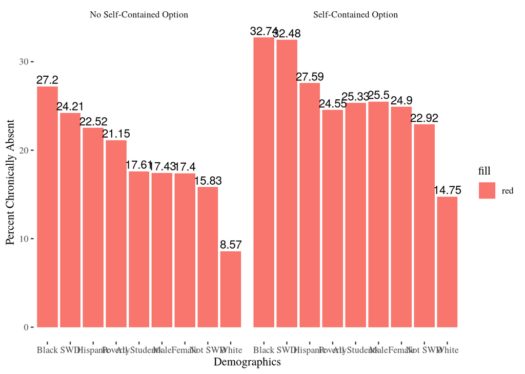

```r
library(readr)
library(tidyverse)
working_data <- read.csv('/cloud/project/data/third_grade_data_cleaned.csv')
## is the average attendance score among SC different than
## average attendance score among non SC
# install.packages("ggthemes")
library(ggthemes)
working_data_graph <- working_data %>%
  filter(Demographic.Variable %in% c("SWD", "All Students",
                                     "White", "Black",
                                     "Male", "Female",
                                     "Hispanic", "Poverty",
                                     "Not SWD")) %>%
  group_by(self_contained_option, Demographic.Variable) %>%
  summarise(mean = mean(Percent_Attendance),
            mean_absent = mean(Percent_Chronically_Absent))
working_data_graph <- working_data_graph %>%
  mutate(self_contained_option = ifelse(self_contained_option == 1, "Self-Contained Option",
                                        "No Self-Contained Option"))
ggplot(data = working_data_graph, aes(x = reorder(Demographic.Variable, -mean_absent),
                                y = mean_absent,
                                fill = "red")) +
         geom_bar(sta = "identity") +
  facet_wrap(~self_contained_option) +
  xlab ("Demographics") +
  ylab("Percent Chronically Absent") +
  theme_tufte() +
  geom_text(aes(label = round(mean_absent,2), vjust = -.3))
```

```r
working_data %>%
  group_by(self_contained_option) %>%
  summarise(mean = mean(X..Students.with.Disabilities))
```

```
## # A tibble: 2 x 2
##   self_contained_option  mean
##                   <int> <dbl>
## 1                     0 0.185
## 2                     1 0.216
```

Differences in covariates

A Welch Two sample T. test confirms that there is a statistically significant difference in the rates of attendance and absenteeism. Attendance rates for the two groups differed significantly according to Welch’s t-test, t(394.4) = 6.84, p <.001. On average, schools with a self contained option have average attendance rates among SPED students of 91.4 %, and schools without a self contained option have average attendance rates among SPED students of 93.0%. A more alarming difference is the difference in chronic absenteeism rates, where the two groups again differed significantly according to Welch’s t-test, t-test, t(351.63) = -5.8884, p <.001. We are 95% confident that the difference between the Chronic Absenteeism rates between school types are from 11 to 5.5%.

```r
library(pacman)
#small sample matching
library(readr)
library(pacman)
p_load(MatchIt, dplyr, survey, tableone, twang, ipw, ggplot2)
working_data <- read.csv('/cloud/project/data/third_grade_data_cleaned.csv')
working_data <- working_data %>%
  filter(Demographic.Variable == "SWD")
working_data %>%
  group_by(self_contained_option) %>%
  summarise(mean_attendance = mean(Percent_Attendance),
            mean_chronic_absent = mean(Percent_Chronically_Absent))
```

```
## # A tibble: 2 x 3
##   self_contained_option mean_attendance mean_chronic_absent
##                   <int>           <dbl>               <dbl>
## 1                     0            93.0                24.2
## 2                     1            91.4                32.5
```

```r
p_load(MatchIt, dplyr, survey, tableone, twang, ipw, ggplot2)
# find the diffrences on the covariates
school_covariates <- c('X..Poverty', 'X..Black', 'X..Male', 'Economic.Need.Index',
                       'X..White', 'X..Female', 'Total.Enrollment', 'X..Students.with.Disabilities')
working_data %>%
  group_by(self_contained_option) %>%
  select(one_of(school_covariates)) %>%
  summarise_all(funs(mean(., na.rm=T)))
```

```
## # A tibble: 2 x 9
##   self_contained_… X..Poverty X..Black X..Male Economic.Need.I… X..White
##              <int>      <dbl>    <dbl>   <dbl>            <dbl>    <dbl>
## 1                0      0.632    0.181   0.506            0.609    0.248
## 2                1      0.804    0.281   0.514            0.765    0.131
## # … with 3 more variables: X..Female <dbl>, Total.Enrollment <dbl>,
## #   X..Students.with.Disabilities <dbl>
```

```r
# do a t.test to find if there are statistically different differences
# lapply(school_covariates, function(v) {
#   t.test(working_data[, v] ~ working_data[ ,'self_contained_option'])
# })
```

### Matching

P(X = 1|X) is the probability that the school does NOT have a SC option P(1): Probability of Treatment (no SC option) P(0): Probability of Control (SC option)

It might seem backwards that the Treatment here is “no self-contained” option, when SC option is usually viewed as a “service”, but since the hypothesis is that schools with no SC option have higher attendance rates, and since 203 treatment schools that do not have a self-contained option, and 534 control schools do have a self-contained option, we define no SC as the Treatment.

```r
###
##PART 1 MATCHING with Propensity Score
###
library(readr)
library(pacman)
p_load(MatchIt, dplyr, survey, tableone, twang, ipw, ggplot2)
working_data <- read.csv('/cloud/project/data/third_grade_data_cleaned.csv')
working_data <- working_data %>%
  filter(Demographic.Variable == "SWD")


working_data %>%
  group_by(self_contained_option) %>%
  summarise(mean_attendance = mean(Percent_Attendance),
            mean_chronic_absent = mean(Percent_Chronically_Absent))
```

```
## # A tibble: 2 x 3
##   self_contained_option mean_attendance mean_chronic_absent
##                   <int>           <dbl>               <dbl>
## 1                     0            93.0                24.2
## 2                     1            91.4                32.5
```

```r
with(working_data, t.test(Percent_Attendance ~ self_contained_option))
```

```
##
##  Welch Two Sample t-test
##
## data:  Percent_Attendance by self_contained_option
## t = 6.8404, df = 394.4, p-value = 3.024e-11
## alternative hypothesis: true difference in means is not equal to 0
## 95 percent confidence interval:
##  1.122526 2.028028
## sample estimates:
## mean in group 0 mean in group 1
##        93.00936        91.43408
```

```r
with(working_data, t.test(Percent_Chronically_Absent ~ self_contained_option))
```

```
##
##  Welch Two Sample t-test
##
## data:  Percent_Chronically_Absent by self_contained_option
## t = -5.884, df = 351.63, p-value = 9.335e-09
## alternative hypothesis: true difference in means is not equal to 0
## 95 percent confidence interval:
##  -11.022223  -5.499767
## sample estimates:
## mean in group 0 mean in group 1
##        24.21429        32.47528
```

```r
table(working_data$self_contained_option)
```

```
##
##   0   1
## 203 534
```

```r
## the t test is statistically signifiant, but that
# is done without any matching
# find the diffrences on the covariates
school_covariates <- c('X..Poverty', 'X..Black', 'X..Male', 'Economic.Need.Index',
                       'X..White', 'X..Female', 'Total.Enrollment', 'X..Students.with.Disabilities')
working_data %>%
  group_by(self_contained_option) %>%
  select(one_of(school_covariates)) %>%
  summarise_all(funs(mean(., na.rm=T)))
```

```
## # A tibble: 2 x 9
##   self_contained_… X..Poverty X..Black X..Male Economic.Need.I… X..White
##              <int>      <dbl>    <dbl>   <dbl>            <dbl>    <dbl>
## 1                0      0.632    0.181   0.506            0.609    0.248
## 2                1      0.804    0.281   0.514            0.765    0.131
## # … with 3 more variables: X..Female <dbl>, Total.Enrollment <dbl>,
## #   X..Students.with.Disabilities <dbl>
```

```r
# do a t.test to find if there are statistically different differences

lapply(school_covariates, function(v) {
  t.test(working_data[, v] ~ working_data[ ,'self_contained_option'])
})
```

```
## [[1]]
##
##  Welch Two Sample t-test
##
## data:  working_data[, v] by working_data[, "self_contained_option"]
## t = -7.8428, df = 261.44, p-value = 1.124e-13
## alternative hypothesis: true difference in means is not equal to 0
## 95 percent confidence interval:
##  -0.2149956 -0.1287040
## sample estimates:
## mean in group 0 mean in group 1
##       0.6322906       0.8041404
##
##
## [[2]]
##
##  Welch Two Sample t-test
##
## data:  working_data[, v] by working_data[, "self_contained_option"]
## t = -5.072, df = 444.37, p-value = 5.791e-07
## alternative hypothesis: true difference in means is not equal to 0
## 95 percent confidence interval:
##  -0.13913838 -0.06142434
## sample estimates:
## mean in group 0 mean in group 1
##       0.1806700       0.2809513
##
##
## [[3]]
##
##  Welch Two Sample t-test
##
## data:  working_data[, v] by working_data[, "self_contained_option"]
## t = -3.8629, df = 359.18, p-value = 0.0001329
## alternative hypothesis: true difference in means is not equal to 0
## 95 percent confidence interval:
##  -0.012454552 -0.004051417
## sample estimates:
## mean in group 0 mean in group 1
##       0.5056946       0.5139476
```

[output cut: 55 more lines]

```
##        562.1232        656.2547
##
##
## [[8]]
##
##  Welch Two Sample t-test
##
## data:  working_data[, v] by working_data[, "self_contained_option"]
## t = -6.7499, df = 448.86, p-value = 4.587e-11
## alternative hypothesis: true difference in means is not equal to 0
## 95 percent confidence interval:
##  -0.04093240 -0.02247186
## sample estimates:
## mean in group 0 mean in group 1
##       0.1899458       0.2216479
```

```r
# set seed
set.seed(1731)
## issue with the matching, so what if we switch treatment and control
working_data$treatment_indicator <- ifelse(working_data$self_contained_option == 1, 0, 1)
working_data$new_outcome_labelled <- ifelse(working_data$treatment_indicator == 1, "no SC", "SC")
library(MatchIt)

school_nearest <- matchit(formula = treatment_indicator ~ Economic.Need.Index +
                            X..Black + X..Male + X..Poverty + X..Female + X..White #+ Total.Enrollment
                          + X..Students.with.Disabilities
                          , data = working_data,
                          method = "nearest",
                          family = "binomial",
                          caliper = 0.25)
summary(school_nearest)
```

```
##
## Call:
## matchit(formula = treatment_indicator ~ Economic.Need.Index +
##     X..Black + X..Male + X..Poverty + X..Female + X..White +
##     X..Students.with.Disabilities, data = working_data, method = "nearest",
##     family = "binomial", caliper = 0.25)
##
## Summary of balance for all data:
##                               Means Treated Means Control SD Control Mean Diff
## distance                             0.3824        0.2348     0.1333    0.1476
## Economic.Need.Index                  0.6092        0.7655     0.1955   -0.1563
## X..Black                             0.1807        0.2810     0.2757   -0.1003
## X..Male                              0.5057        0.5139     0.0256   -0.0083
## X..Poverty                           0.6323        0.8041     0.1785   -0.1718
## X..Female                            0.4943        0.4861     0.0256    0.0083
## X..White                             0.2480        0.1309     0.1932    0.1171
## X..Students.with.Disabilities        0.1899        0.2216     0.0659   -0.0317
##                               eQQ Med eQQ Mean eQQ Max
## distance                       0.1152   0.1478  0.3291
## Economic.Need.Index            0.1560   0.1550  0.3450
## X..Black                       0.0800   0.1002  0.3150
## X..Male                        0.0080   0.0086  0.0650
## X..Poverty                     0.1430   0.1705  0.4090
## X..Female                      0.0090   0.0089  0.0650
## X..White                       0.0910   0.1174  0.2980
## X..Students.with.Disabilities  0.0320   0.0314  0.0620
##
##
## Summary of balance for matched data:
##                               Means Treated Means Control SD Control Mean Diff
## distance                             0.3305        0.3206     0.1634    0.0100
## Economic.Need.Index                  0.6670        0.6813     0.2290   -0.0143
## X..Black                             0.1986        0.2145     0.2556   -0.0159
## X..Male                              0.5082        0.5055     0.0213    0.0027
## X..Poverty                           0.6973        0.7168     0.2177   -0.0195
## X..Female                            0.4918        0.4945     0.0213   -0.0027
## X..White                             0.2065        0.1843     0.2154    0.0222
## X..Students.with.Disabilities        0.1943        0.1966     0.0623   -0.0022
##                               eQQ Med eQQ Mean eQQ Max
## distance                       0.0076   0.0117  0.0425
```

[output cut: 10 more lines]

```
## distance                         93.2518 93.3876  92.0796 87.0715
## Economic.Need.Index              90.8355 94.2308  86.5024 67.8261
## X..Black                         84.1532 92.5000  77.8594 57.4603
## X..Male                          67.2499 75.0000  55.5731  6.1538
## X..Poverty                       88.6446 90.9091  82.2855 50.3667
## X..Female                        67.2499 77.7778  56.8058  6.1538
## X..White                         81.0323 85.7143  80.0730 59.7315
## X..Students.with.Disabilities    92.9703 81.2500  76.1818 30.6452
##
## Sample sizes:
##           Control Treated
## All           534     203
## Matched       175     175
## Unmatched     359      28
## Discarded       0       0
```

```r
table(working_data$treatment_indicator)
```

```
##
##   0   1
## 534 203
```

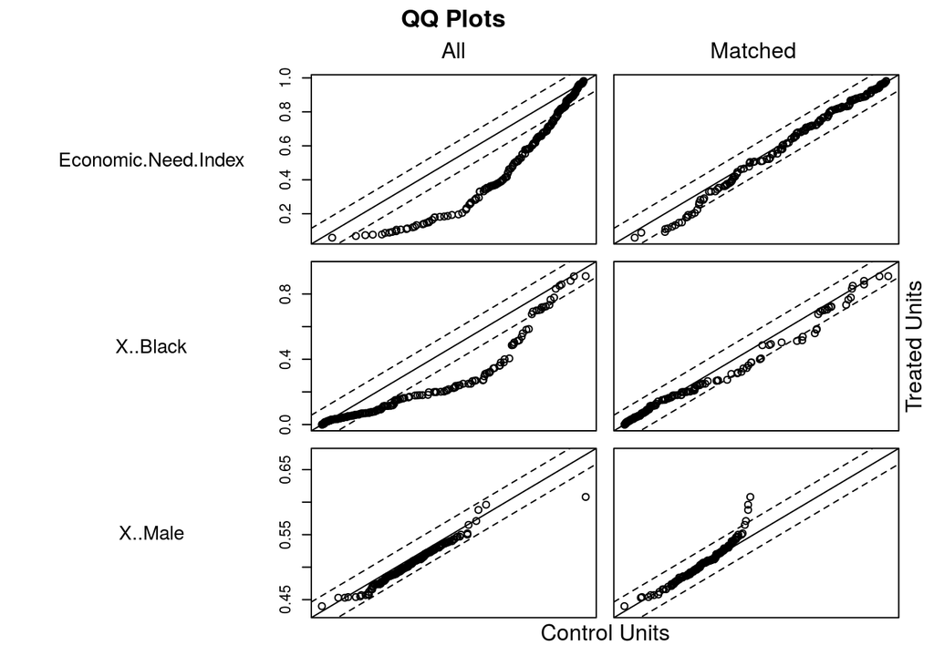

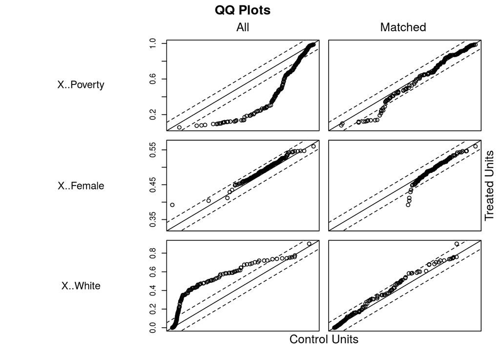

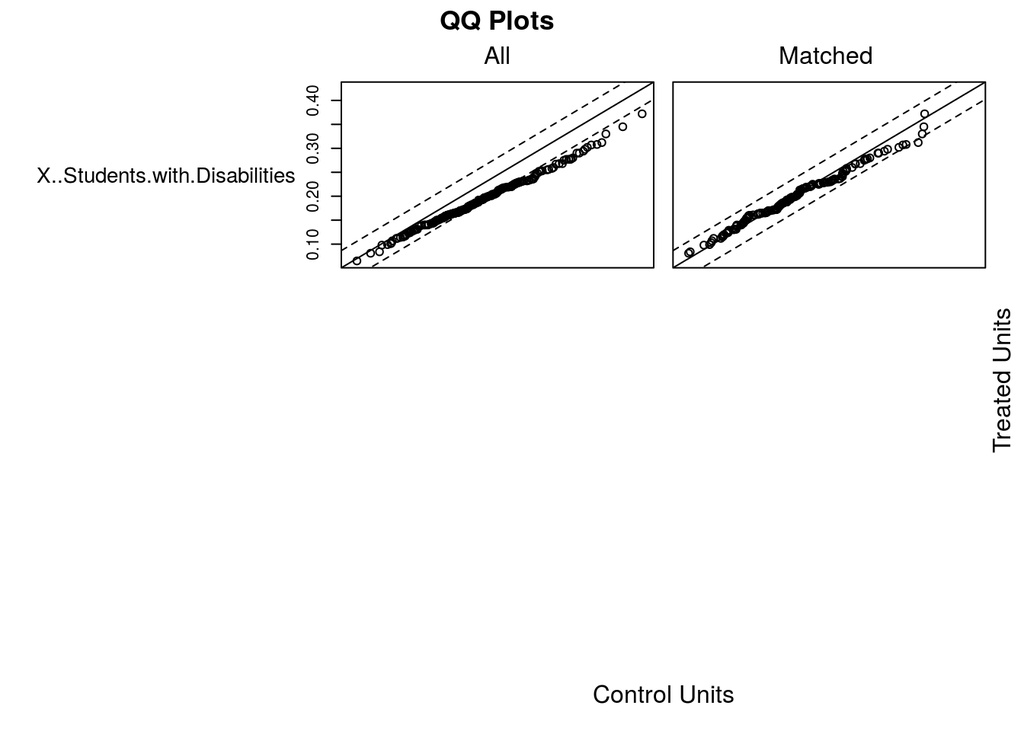

```r
plot(school_nearest)
```

```r
#create the matched set
nearest_matched <- match.data(school_nearest)

#350 schools were matched
dim(nearest_matched)
```

```
## [1] 350  20
```

```r
## now look at the means of the covariates
#matching was successful because the poverty rates are around .72 now together
nearest_matched %>%
  group_by(self_contained_option) %>%
  select(X..Poverty) %>%
  summarise_all(funs(mean))
```

```
## # A tibble: 2 x 2
##   self_contained_option X..Poverty
##                   <int>      <dbl>
## 1                     0      0.697
## 2                     1      0.717
```

```r
## also can conduct a t test to assess the matches
with(nearest_matched, t.test(Percent_Attendance ~self_contained_option))
```

```
##
##  Welch Two Sample t-test
##
## data:  Percent_Attendance by self_contained_option
## t = 1.2618, df = 347.85, p-value = 0.2079
## alternative hypothesis: true difference in means is not equal to 0
## 95 percent confidence interval:
##  -0.2049849  0.9386992
## sample estimates:
## mean in group 0 mean in group 1
##        92.69657        92.32971
```

```r
### ## estimating treatment effects with matched data
model <- lm(Percent_Attendance ~ treatment_indicator, data = nearest_matched)
summary(model)
```

```
##
## Call:
## lm(formula = Percent_Attendance ~ treatment_indicator, data = nearest_matched)
##
## Residuals:
##     Min      1Q  Median      3Q     Max
## -7.1297 -1.5966  0.2369  2.0951  6.5703
##
## Coefficients:
##                     Estimate Std. Error t value Pr(>|t|)
## (Intercept)          92.3297     0.2056 449.099   <2e-16 ***
## treatment_indicator   0.3669     0.2907   1.262    0.208
## ---
## Signif. codes:  0 '***' 0.001 '**' 0.01 '*' 0.05 '.' 0.1 ' ' 1
##
## Residual standard error: 2.72 on 348 degrees of freedom
## Multiple R-squared:  0.004554,   Adjusted R-squared:  0.001694
## F-statistic: 1.592 on 1 and 348 DF,  p-value: 0.2079
```

```r
table(nearest_matched$treatment_indicator)
```

```
##
##   0   1
## 175 175
```

```r
# if self contained is 1 (treatment), you have SC option, you have higher attenance
## treatment effects without matched data
model <- lm(Percent_Attendance ~ treatment_indicator, data = working_data)
summary(model)
```

```
##
## Call:
## lm(formula = Percent_Attendance ~ treatment_indicator, data = working_data)
##
## Residuals:
##      Min       1Q   Median       3Q      Max
## -11.3341  -1.7341   0.3659   2.1659   7.4659
##
## Coefficients:
##                     Estimate Std. Error t value Pr(>|t|)
## (Intercept)          91.4341     0.1255 728.437  < 2e-16 ***
## treatment_indicator   1.5753     0.2392   6.587 8.58e-11 ***
## ---
## Signif. codes:  0 '***' 0.001 '**' 0.01 '*' 0.05 '.' 0.1 ' ' 1
##
## Residual standard error: 2.901 on 735 degrees of freedom
## Multiple R-squared:  0.05573,    Adjusted R-squared:  0.05445
## F-statistic: 43.38 on 1 and 735 DF,  p-value: 8.577e-11
```

### IPTW

```r
## IPTW
#add the propensity scores
working_data$ps <- school_nearest$distance
#estimate the effect of SC option using IPTW
#create IPTW weights - 0 is no SC, which is the treatment
working_data$iptw <- ifelse(working_data$new_outcome_labelled == 'no SC', 1/(working_data$ps),
                            1/(1-working_data$ps))
#stabilized weights
working_data$stable.iptw <- ifelse(working_data$new_outcome_labelled == 'no SC',
                                   (mean(working_data$ps[working_data$new_outcome_labelled == 'no SC'])/working_data$ps),
                                   (mean(1-working_data$ps[working_data$new_outcome_labelled == 'SC'])/(1-working_data$ps)))
working_data_nomiss<- working_data %>%
  select(Percent_Attendance, treatment_indicator, X..Poverty, X..Male, X..Black,
         Economic.Need.Index, X..Female, X..White, X..Students.with.Disabilities, ps, iptw, stable.iptw,
         treatment_indicator)
#weighted data - create a weighted version of the data
working_data_weighted <- svydesign(ids = ~1, data = working_data_nomiss, weights = working_data_nomiss$iptw)
#check the balance
SC_iptw_table <- svyCreateTableOne(vars = school_covariates, strata = "treatment_indicator", data = working_data_weighted,
                                   test = F)
SC_iptw_table
```

```
##                                            Stratified by treatment_indicator
##                                             0             1
##   n                                         730.65        752.05
##   X..Poverty (mean (SD))                      0.77 (0.21)   0.77 (0.24)
##   X..Black (mean (SD))                        0.26 (0.27)   0.24 (0.25)
##   X..Male (mean (SD))                         0.51 (0.03)   0.51 (0.03)
##   Economic.Need.Index (mean (SD))             0.73 (0.22)   0.73 (0.24)
##   X..White (mean (SD))                        0.15 (0.21)   0.15 (0.20)
##   X..Female (mean (SD))                       0.49 (0.03)   0.49 (0.03)
##   X..Students.with.Disabilities (mean (SD))   0.21 (0.07)   0.21 (0.06)
```

```r
print(SC_iptw_table, smd=T)
```

```
##                                            Stratified by treatment_indicator
##                                             0             1             SMD
##   n                                         730.65        752.05
##   X..Poverty (mean (SD))                      0.77 (0.21)   0.77 (0.24)  0.006
##   X..Black (mean (SD))                        0.26 (0.27)   0.24 (0.25)  0.069
##   X..Male (mean (SD))                         0.51 (0.03)   0.51 (0.03)  0.085
##   Economic.Need.Index (mean (SD))             0.73 (0.22)   0.73 (0.24)  0.004
##   X..White (mean (SD))                        0.15 (0.21)   0.15 (0.20)  0.005
##   X..Female (mean (SD))                       0.49 (0.03)   0.49 (0.03)  0.085
##   X..Students.with.Disabilities (mean (SD))   0.21 (0.07)   0.21 (0.06)  0.023
```

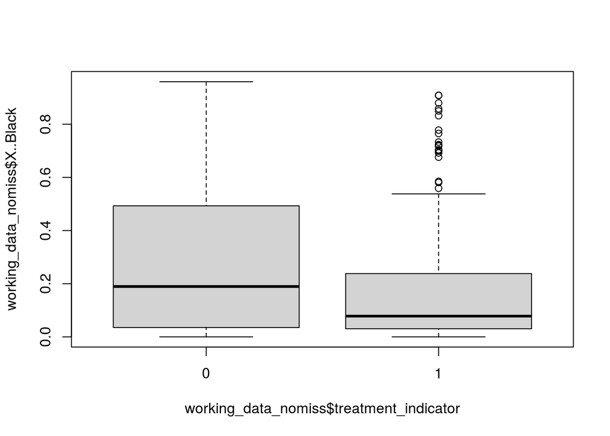

```r
boxplot(working_data_nomiss$X..Black ~ working_data_nomiss$treatment_indicator)
```

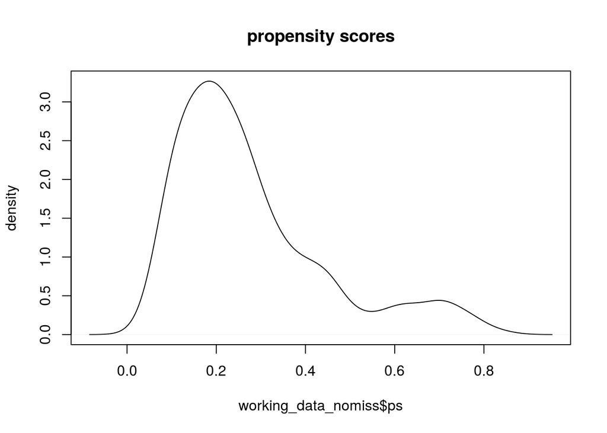

```r
### check the covariate distribution for all the weights

for(i in 1:nrow(working_data_nomiss)){
  working_data_nomiss$X..Black[i] <- ifelse(working_data_nomiss$treatment_indicator == 1,
                                            (working_data_nomiss$X..Black[i]*(mean(working_data_nomiss$ps[working_data_nomiss$treatment_indicator==1])))/working_data_nomiss$ps[i],
                                            (mean(1-(working_data_nomiss$ps[working_data_nomiss$treatment_indicator ==0]))*working_data_nomiss$X..Black[i])/(1-working_data_nomiss$ps[i]))
}
# plot the weights
ipwplot(working_data_nomiss$ps, logscale = F,
        main = "propensity scores")
```

```r
#lastly, test if distributions of covaraites are similar/diffeernt before or after weighting
ks.test(working_data_nomiss$X..Black[working_data_nomiss$treatment_indicator == 1],
        working_data_nomiss$X..Black[working_data_nomiss$treatment_indicator == 0])
```

```
##
##  Two-sample Kolmogorov-Smirnov test
##
## data:  working_data_nomiss$X..Black[working_data_nomiss$treatment_indicator == 1] and working_data_nomiss$X..Black[working_data_nomiss$treatment_indicator == 0]
## D = 0.24376, p-value = 5.127e-08
## alternative hypothesis: two-sided
```

```r
#estimate the ate
mod_out_iptw <- lm(Percent_Attendance ~ treatment_indicator, weights = working_data_nomiss$iptw,
                   data = working_data_nomiss)
##sig ate here
summary(mod_out_iptw)
```

```
##
## Call:
## lm(formula = Percent_Attendance ~ treatment_indicator, data = working_data_nomiss,
##     weights = working_data_nomiss$iptw)
##
## Weighted Residuals:
##      Min       1Q   Median       3Q      Max
## -17.3193  -2.0694   0.4174   2.8616  11.9543
##
## Coefficients:
##                     Estimate Std. Error t value Pr(>|t|)
## (Intercept)          91.6968     0.1518 604.197   <2e-16 ***
## treatment_indicator   0.4670     0.2131   2.191   0.0287 *
## ---
## Signif. codes:  0 '***' 0.001 '**' 0.01 '*' 0.05 '.' 0.1 ' ' 1
##
## Residual standard error: 4.102 on 735 degrees of freedom
## Multiple R-squared:  0.006491,   Adjusted R-squared:  0.00514
## F-statistic: 4.802 on 1 and 735 DF,  p-value: 0.02874
```